```python
import utils
import pickle
import pandas as pd
import numpy as np
import seaborn as sns
import matplotlib.pyplot as plt
from sklearn.ensemble import RandomForestClassifier
from sklearn.preprocessing import StandardScaler, PolynomialFeatures
from sklearn.pipeline import Pipeline
from sklearn.model_selection import StratifiedShuffleSplit, StratifiedKFold, GridSearchCV
from utils import XGBC
from sklearn.metrics import confusion_matrix, roc_curve, precision_score, accuracy_score, recall_score
from sklearn.linear_model import LogisticRegression
from sklearn.ensemble import VotingClassifier
from sklearn.naive_bayes import GaussianNB
from skdag import DAGBuilder

df = pd.read_csv('archive/train.csv')
target_var = 'Loan_Status'

# According to data provider 'Home_Ownership' and 'Employment_Duration' columns are mismatched (swap them)
df = utils.ColSwap.transform(df, 'Home_Ownership', 'Employment_Duration')

# I did some exploratory work ahead of time to get these values
drop_cols = ['ID', 'Payment_Plan', 'Accounts_Delinquent']
cat_cols = ['Batch_Enrolled', 'Application_Type', 'Initial_List_Status', 'Grade', 'Sub_Grade', 'Home_Ownership', 'Verification_Status', 'Loan_Title']
features = list(set(df.columns) - set(drop_cols) - {'Loan_Status'})
num_cols = list(set(features) - set(cat_cols))
polynomial_features = ['Total_Current_Balance', 'Last_week_Pay', 'Employment_Duration', 'Interest_Rate', 'Loan_Amount']

df = df.drop(drop_cols, axis=1)

# Loading models that have been cached
nb_clf = pickle.load(open("models/nb_clf.pkl", "rb"))
logr_clf = pickle.load(open("models/logr_clf.pkl", "rb"))
xgb_clf = pickle.load(open("models/xgb_clf.pkl", "rb"))
compound_model = pickle.load(open("models/compound_model.pkl", "rb"))
cm2 = pickle.load(open("models/compound_model_2.pkl", "rb"))
cm3 = pickle.load(open("models/compound_model_3.pkl", "rb"))
```

> Split the data into training and testing sets

```python
stratified_shuffle_split = StratifiedShuffleSplit(n_splits=1, test_size=0.2, random_state=101)
```

```python
for train_index, test_index in stratified_shuffle_split.split(df, df[target_var]):
    df_train = df.iloc[train_index]
    df_test = df.iloc[test_index]
```

```python
# pickle.dump(df_train, open("archive/df_train.pkl", "wb"))
# pickle.dump(df_test, open("archive/df_test.pkl", "wb"))
```

> Let's split off a validation set from the main training set. We will not touch the testing set again until we have a complete model that is "ready for production" so the validation set is what we use until then to get an idea how well our model is generalizing to unseen data.

```python
df_temp = df_train
for train_index, val_index in stratified_shuffle_split.split(df_temp.drop(target_var, axis=1), df_temp[target_var]):
    df_train = df_temp.iloc[train_index]
    df_val = df_temp.iloc[val_index]
del df_temp  # no longer needed
```

```python
X_train, y_train = df_train.iloc[:, :-1], df_train.iloc[:, -1]
X_val, y_val = df_val.iloc[:, :-1], df_val.iloc[:, -1]
```

```python
from utils import Processed
# Layer_1_training_set = Processed(X_train=X_train, y_train=y_train, X_traintest=X_val, y_traintest=y_val)
# pickle.dump(Layer_1_training_set, open("archive/layer_1_training_set.pkl", "wb"))
```

Let's have a look

```python
X_val.head()
```

|  | Loan_Amount | Funded_Amount | Funded_Amount_Investor | Term | Batch_Enrolled | Interest_Rate | Grade | Sub_Grade | Home_Ownership | Employment_Duration | ... | Total_Received_Interest | Total_Received_Late_Fee | Recoveries | Collection_Recovery_Fee | Collection_12_months_Medical | Application_Type | Last_week_Pay | Total_Collection_Amount | Total_Current_Balance | Total_Revolving_Credit_Limit |
| --- | --- | --- | --- | --- | --- | --- | --- | --- | --- | --- | --- | --- | --- | --- | --- | --- | --- | --- | --- | --- | --- |
| 870 | 14111 | 13767 | 9563.746407 | 59 | BAT5525466 | 9.045659 | C | G5 | RENT | 262436.40360 | ... | 11150.271200 | 0.089866 | 1.334796 | 0.877776 | 0 | INDIVIDUAL | 153 | 46 | 158940 | 3558 |
| 8290 | 7614 | 30421 | 11346.088130 | 59 | BAT5525466 | 10.518245 | F | C2 | MORTGAGE | 98053.06953 | ... | 2082.153357 | 0.006100 | 5.763419 | 1.150784 | 0 | INDIVIDUAL | 37 | 30 | 384370 | 3328 |
| 41728 | 16486 | 10917 | 12976.377200 | 58 | BAT2803411 | 6.529727 | D | A5 | MORTGAGE | 41746.23898 | ... | 10946.199030 | 0.045485 | 7.464004 | 0.477469 | 0 | INDIVIDUAL | 27 | 44 | 78590 | 50039 |
| 16861 | 18303 | 4778 | 10642.013100 | 58 | BAT2333412 | 7.336237 | D | A5 | MORTGAGE | 208020.32220 | ... | 1875.260540 | 0.027335 | 4.323850 | 0.325338 | 0 | INDIVIDUAL | 65 | 54 | 185301 | 14222 |
| 4037 | 7211 | 32744 | 12345.409610 | 59 | BAT2333412 | 11.065556 | C | D3 | MORTGAGE | 44023.48685 | ... | 791.055964 | 0.103038 | 2.002997 | 0.237150 | 0 | INDIVIDUAL | 126 | 36 | 341048 | 66184 |

5 rows × 31 columns

## The Numerical Features

> Now that the data is a bit cleaner I wanted to get some statistics. The heatmap below unfortunately shows that none of the numerical variables are directly correlated with the target variable (nor with each other). I think basically that means this is going to be difficult.

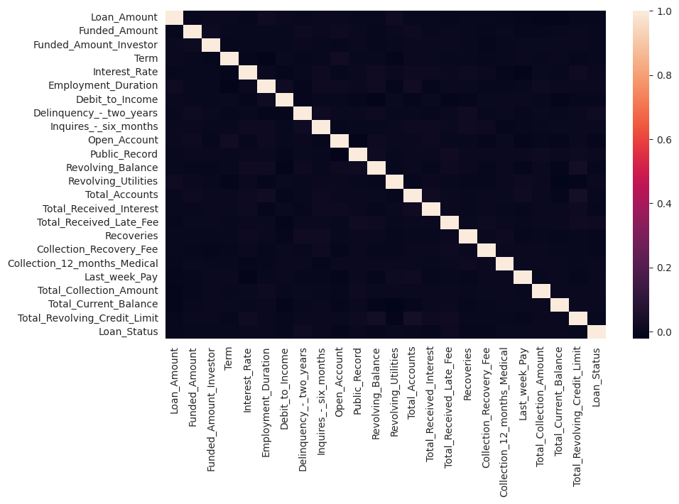

```python
correlations = df_train.corr(numeric_only=True)
plt.figure(figsize=(10,6))
sns.heatmap(correlations)
```

```python
defaulted = df_train.Loan_Status == 1
not_defaulted = df_train.Loan_Status == 0
```

> Another great way to visualize this lack of correlation is to show that the distributions of the features are effectively identical with respect to the target variable. Here I've chosen four features but this behavior extends to the entire set of numerical features.

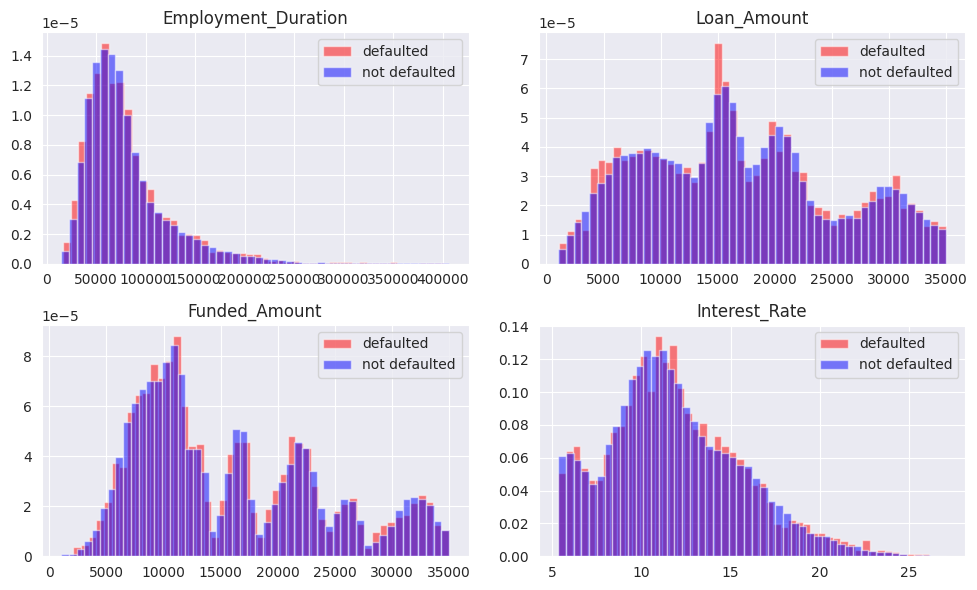

```python
cols = 2
fig, ax = plt.subplots(2, cols, figsize=(10,6))

for i, feature in enumerate(['Employment_Duration', 'Loan_Amount', 'Funded_Amount', 'Interest_Rate']):
    ax[i//cols, i%cols].hist(X_train[defaulted][feature], bins=50, alpha=0.5, density=True, color='red', label='defaulted')
    ax[i//cols, i%cols].hist(X_train[not_defaulted][feature], bins=50, alpha=0.5, density=True, color='blue', label='not defaulted')
    ax[i//cols, i%cols].legend()
    ax[i//cols, i%cols].set_title(feature)

plt.tight_layout()
plt.show()
```

# Now for the categorical data

```python
cat_cols
```

```
['Batch_Enrolled',
 'Application_Type',
 'Initial_List_Status',
 'Grade',
 'Sub_Grade',
 'Home_Ownership',
 'Verification_Status',
 'Loan_Title']
```

```python
contingency_tables = []
for feature in list(set(cat_cols) - {'Application_Type', 'Initial_List_Status', 'Loan_Title'}):
    contingency_tables.append(pd.crosstab(X_train[feature], y_train))
```

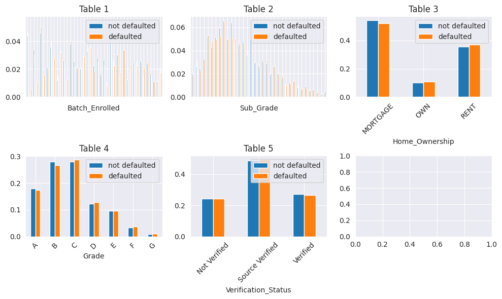

```python
cols = 3
fig, ax = plt.subplots(2, cols, figsize=(10, 6))
for i, ct in enumerate(contingency_tables):
    ct.div(ct.sum(axis=0), axis=1).plot.bar(ax=ax[i//cols, i%cols], legend=False)
    if len(ct.index) > 8:
        ax[i//cols, i%cols].set_xticklabels('')
    else:
        ax[i//cols, i%cols].set_xticklabels(ct.index, rotation=45)
    ax[i//cols, i%cols].set_title('Table {}'.format(i+1))
    ax[i//cols, i%cols].legend(labels={'not defaulted': 0, 'defaulted': 1})
plt.tight_layout()
plt.show()
```

> I had naively hoped that the loan grading system would hold a lot of useful information as far as likelyhood of default goes. This is what happens when you pick a project that exists in a domain of which you are entirely clueless. Looking at the chart for 'Loan_Title', it's an absolute disaster (Hi, future Zach here, I removed that chart). There are 109 unique values in that category. However, there is a *lot* of overlap amongst the categories, so I opted to map the large set onto a smaller set.

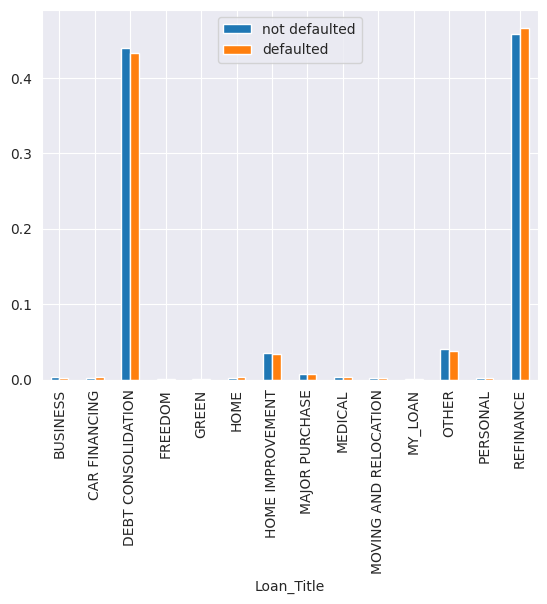

```python
ct = pd.crosstab(utils.LoanTitleMapper().transform(X_train).Loan_Title, y_train)
ct.div(ct.sum(axis=0), axis=1).plot.bar(legend=False)
plt.legend(labels={'not defaulted': 0, 'defaulted': 1})
```

> I mapped the original 109 values onto the 14 values you see above. I also decided to create the same bar chart again, minus the four most frequent categories, to give us some resolution on the less frequent categories.

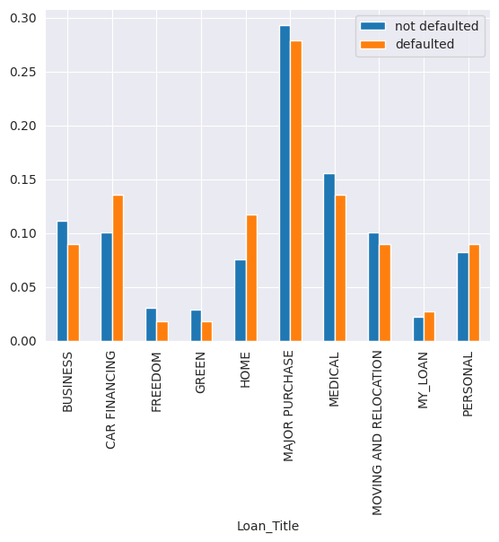

```python
tallest = {"REFINANCE", "DEBT CONSOLIDATION", "OTHER", "HOME IMPROVEMENT"}
ct = (
    pd.crosstab(
        utils.LoanTitleMapper()
        .transform(X_train)
        .query('Loan_Title not in @tallest')
        .Loan_Title, y_train
    )
)
ct.div(ct.sum(axis=0), axis=1).plot.bar(legend=False)
plt.legend(labels={'not defaulted': 0, 'defaulted': 1})
```

## Building Pipelines and Testing Models

```python
pipe = utils.build_pre_pipe()
pipe.show(detailed=True)
```

[figure not shown]

> We can now perform this sequence of transformations on the features simply by invoking the DAG object's `fit_transform` method (or just `transform` depending on context).

```python
pipe.fit_transform(X_train).head()
```

|  | impute__scale__Loan_Amount | impute__scale__Funded_Amount | impute__scale__Funded_Amount_Investor | impute__scale__Term | impute__scale__Interest_Rate | impute__scale__Employment_Duration | impute__scale__Debit_to_Income | impute__scale__Delinquency_-_two_years | impute__scale__Inquires_-_six_months | impute__scale__Open_Account | ... | impute__scale__Loan_Title_GREEN | impute__scale__Loan_Title_HOME | impute__scale__Loan_Title_HOME IMPROVEMENT | impute__scale__Loan_Title_MAJOR PURCHASE | impute__scale__Loan_Title_MEDICAL | impute__scale__Loan_Title_MOVING AND RELOCATION | impute__scale__Loan_Title_MY_LOAN | impute__scale__Loan_Title_OTHER | impute__scale__Loan_Title_PERSONAL | impute__scale__Loan_Title_REFINANCE |
| --- | --- | --- | --- | --- | --- | --- | --- | --- | --- | --- | --- | --- | --- | --- | --- | --- | --- | --- | --- | --- | --- |
| 12250 | -0.712987 | -0.161518 | -0.681825 | -0.052135 | -1.402186 | -0.666284 | -0.995702 | -0.408865 | -0.304302 | -0.362544 | ... | -0.026369 | -0.044934 | -0.19037 | -0.086139 | -0.062313 | -0.050077 | -0.02407 | -0.205105 | -0.045704 | 1.084178 |
| 37025 | 0.442972 | -0.834452 | -0.433726 | -0.052135 | 1.140762 | -1.006263 | 0.131894 | -0.408865 | -0.304302 | -0.201291 | ... | -0.026369 | -0.044934 | -0.19037 | -0.086139 | -0.062313 | -0.050077 | -0.02407 | -0.205105 | -0.045704 | 1.084178 |
| 28629 | 0.172411 | 1.755888 | -1.013907 | 0.248317 | -0.674973 | -0.613009 | -0.602927 | 0.834140 | -0.304302 | 0.443724 | ... | -0.026369 | -0.044934 | -0.19037 | -0.086139 | -0.062313 | -0.050077 | -0.02407 | -0.205105 | -0.045704 | 1.084178 |
| 43066 | -0.216978 | -0.769270 | -1.450515 | 0.248317 | -0.453639 | 0.618446 | 0.018556 | 0.834140 | -0.304302 | -0.523798 | ... | -0.026369 | -0.044934 | -0.19037 | -0.086139 | -0.062313 | -0.050077 | -0.02407 | -0.205105 | -0.045704 | -0.922358 |
| 20484 | -0.439793 | 0.938228 | 0.353572 | 0.248317 | 0.355580 | 0.489175 | -0.642981 | -0.408865 | 6.111003 | -0.846305 | ... | -0.026369 | -0.044934 | -0.19037 | -0.086139 | -0.062313 | -0.050077 | -0.02407 | -0.205105 | -0.045704 | -0.922358 |

5 rows × 130 columns

> At this point we can start toying around with some models.

```
Fitting 3 folds for each of 100 candidates, totalling 300 fits
```

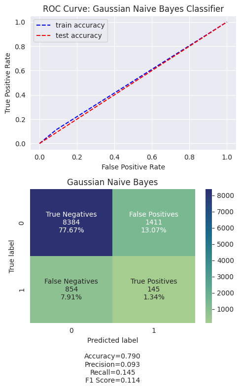

```python
title = 'Gaussian Naive Bayes'

kwargs = {
    "cmap": "crest",
    "group_names": ["True Negatives","False Positives","False Negatives","True Positives"],
    "title": title
}

params_NB = {'var_smoothing': np.logspace(0,-9, num=100)}
gs_NB = GridSearchCV(
    estimator=GaussianNB(var_smoothing=0.0003511191734215131),
    param_grid=params_NB,
    cv=3,
    verbose=1,
    scoring='recall'
)

preproc = utils.build_pre_pipe()
X_train_temp = preproc.fit_transform(X_train).values
X_val_temp = preproc.transform(X_val).values

gs_NB.fit(X_train_temp, y_train)
train_pred = gs_NB.predict(X_train_temp)
predictions = gs_NB.predict(X_val_temp)

fig, (ax1, ax2) = plt.subplots(2, 1, figsize=(5, 8))

fpr, tpr, _ = roc_curve(train_pred, y_train)
fprts, tprts, _ = roc_curve(predictions, y_val)
utils.plot_roc(ax1, fpr,tpr,fprts,tprts,'Gaussian Naive Bayes Classifier')

cm = confusion_matrix(y_val, predictions)
utils.make_confusion_matrix(cm, ax2, **kwargs)
fig.tight_layout()
```

```python
gs_NB.best_params_
```

```
{'var_smoothing': 0.0003511191734215131}
```

> If you know how to read an ROC curve you'll immediately notice that the model is underfit. That's to be expected as this is a very tough dataset and naive Bayes is a simple model.

> Anyhow. Now that we identified a good value for 'var_smoothing' we can build a larger pipeline that contains the entire pre-processing pipeline as a single node.

```python
nb_clf = (
    DAGBuilder()

    .add_step(
        "preprocess_nb",
        utils.build_pre_pipe()
    )

    .add_step(
        "NaiveBayes",
        GaussianNB(var_smoothing=0.0003511191734215131),  # hyperparameter value found experimentally
        deps=["preprocess_nb"]
    )
).make_dag()

nb_clf.show()
```

```python
nb_clf.fit(X_train, y_train)
print(nb_clf.score(X_train, y_train))
print(nb_clf.score(X_val, y_val))
```

```
0.7922225310357606
0.7901612006670372
```

> For training a different model, we might want to use polynomial features. The pre-processing pipline builder can handle that too.

```python
pipe = utils.build_pre_pipe(features=features, polynomial_features=polynomial_features, degree=2)
pipe.show(detailed=True)
```

[figure not shown]

```
Fitting 2 folds for each of 4 candidates, totalling 8 fits
Fitting 2 folds for each of 4 candidates, totalling 8 fits
Fitting 2 folds for each of 4 candidates, totalling 8 fits
Fitting 2 folds for each of 4 candidates, totalling 8 fits
Fitting 2 folds for each of 4 candidates, totalling 8 fits
Fitting 2 folds for each of 4 candidates, totalling 8 fits
```

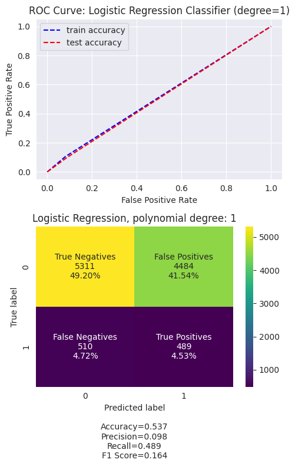

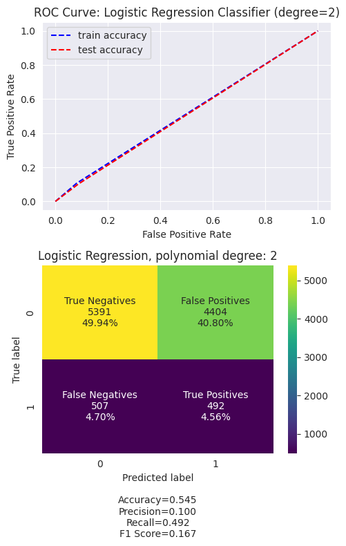

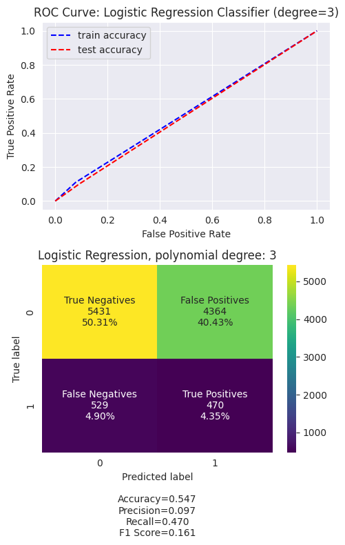

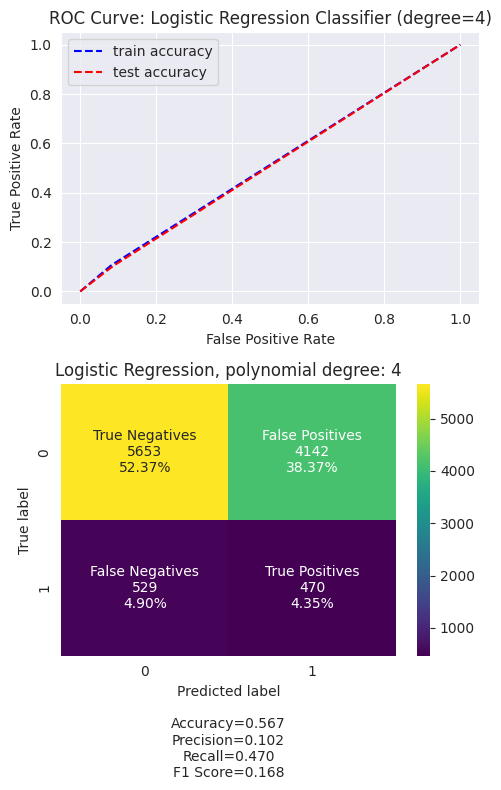

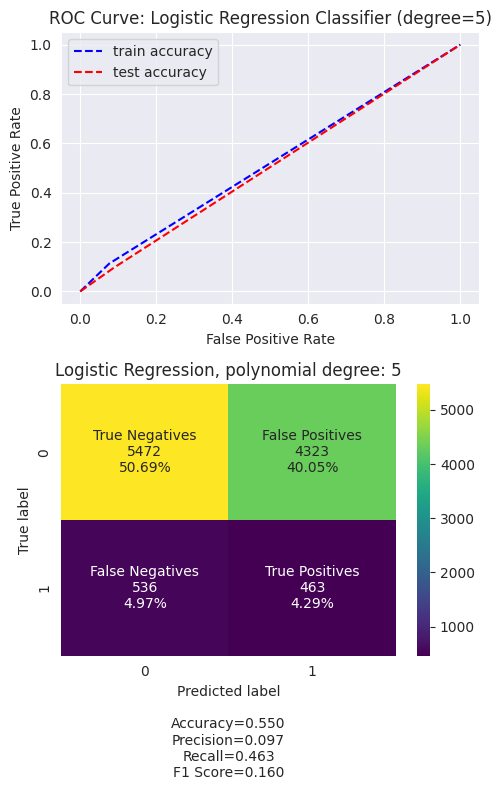

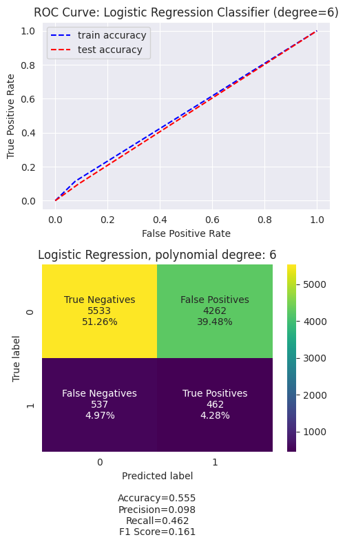

```python
start = 1  # the degree to start the search
stop = 6  # the degree to stop the search
grid_collection = []

for degree in range(start, stop + 1):

    title = f'Logistic Regression, polynomial degree: {degree}'
    kwargs = {
        "cmap": "viridis",
        "group_names": ["True Negatives","False Positives","False Negatives","True Positives"],
        "title": title
    }

    param_grid = {
        "solver": ["newton-cholesky"],
        "class_weight": ["balanced"],
        "C": [1e-5, 1e-1, 1e1, 5e1],
        "n_jobs": [-1]
    }
    gs_logr = GridSearchCV(
        estimator=LogisticRegression(),
        param_grid=param_grid,
        cv=2,
        verbose=1,
        scoring='precision'
    )

    preproc = utils.build_pre_pipe(features, degree=degree, polynomial_features=polynomial_features)
    X_train_temp = preproc.fit_transform(X_train).values
    X_val_temp = preproc.transform(X_val).values

    gs_logr.fit(X_train_temp, y_train)
    train_pred = gs_logr.predict(X_train_temp)
    predictions = gs_logr.predict(X_val_temp)

    grid_collection.append(gs_logr)


    fig, (ax1, ax2) = plt.subplots(2, 1, figsize=(5, 8))

    fpr, tpr, _ = roc_curve(train_pred, y_train)
    fprts, tprts, _ = roc_curve(predictions, y_val)
    utils.plot_roc(ax1, fpr,tpr,fprts,tprts,f'Logistic Regression Classifier (degree={degree})')

    cm = confusion_matrix(y_val, predictions)
    utils.make_confusion_matrix(cm, ax2, **kwargs)
    fig.tight_layout()
```

> The best performance we got was at degree=4, so we'll take the best fit hyperparameters for that trial and use them (making sure to preprocess the data the same way it was for that iteration)

```python
for gs in grid_collection:
    print(gs.best_params_)
```

```
{'C': 1e-05, 'class_weight': 'balanced', 'n_jobs': -1, 'solver': 'newton-cholesky'}
{'C': 1e-05, 'class_weight': 'balanced', 'n_jobs': -1, 'solver': 'newton-cholesky'}
{'C': 10.0, 'class_weight': 'balanced', 'n_jobs': -1, 'solver': 'newton-cholesky'}
{'C': 1e-05, 'class_weight': 'balanced', 'n_jobs': -1, 'solver': 'newton-cholesky'}
{'C': 0.1, 'class_weight': 'balanced', 'n_jobs': -1, 'solver': 'newton-cholesky'}
{'C': 0.1, 'class_weight': 'balanced', 'n_jobs': -1, 'solver': 'newton-cholesky'}
```

```python
logr_params = {'C': 1e-05, 'class_weight': 'balanced', 'n_jobs': -1, 'solver': 'newton-cholesky'}

logr_clf = (
    DAGBuilder()

    .add_step(
        "preproc_logr",
        utils.build_pre_pipe(features, polynomial_features=polynomial_features, degree=4)
    )

    .add_step(
        "logr",
        LogisticRegression(**logr_params),
        deps=["preproc_logr"]
    )
).make_dag()

logr_clf
```

```python
logr_clf.fit(X_train, y_train)
print(logr_clf.score(X_train, y_train))
print(logr_clf.score(X_val, y_val))
```

```
0.573420418751158
0.5672595886603669
```

> Now we should be able to create a pipeline that will let us pass in the orignial, untouched 'X_train' and get a model fit for both naive bayes and logistic regression at the same time, with each model recieving its own uniquely preprocessed features.

```python
compound_model = (
    DAGBuilder()

    .add_step(
        "input",
        "passthrough"
    )

    .add_step(
        "naive bayes",
        nb_clf,
        deps=["input"]
    )

    .add_step(
        "logistic reg",
        logr_clf,
        deps=["input"]
    )
)
```

```python
# pickle.dump(compound_model, open("models/compound_model_builder.pkl", "wb"))
```

```python
cm1 = compound_model.make_dag().fit(X_train, y_train)
```

```python
cm1
```

[figure not shown]

```python
cm1.score(X_val, y_val)
```

```
{'logistic reg': 0.5672595886603669, 'naive bayes': 0.7901612006670372}
```

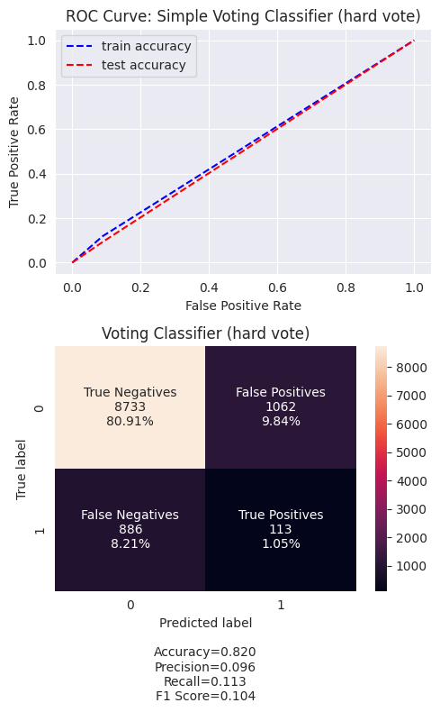

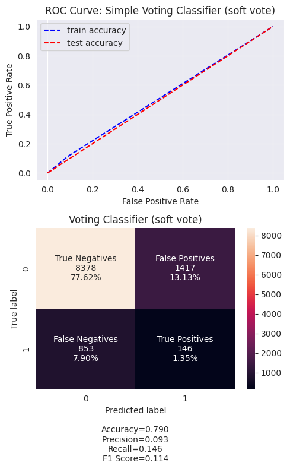

```python
for vote_type in ['hard', 'soft']:

    voting_clf = VotingClassifier(
        estimators=[('logr_clf', logr_clf), ('nb_clf', nb_clf)],
        voting=vote_type
    )


    kwargs = {
        "cmap": "rocket",
        "group_names": ["True Negatives","False Positives","False Negatives","True Positives"],
        "title": f'Voting Classifier ({vote_type} vote)'
    }

    voting_clf.fit(X_train, y_train)
    train_pred = voting_clf.predict(X_train)
    predictions = voting_clf.predict(X_val)

    fig, (ax1, ax2) = plt.subplots(2, 1, figsize=(5, 8))

    fpr, tpr, _ = roc_curve(train_pred, y_train)
    fprts, tprts, _ = roc_curve(predictions, y_val)
    utils.plot_roc(ax1, fpr,tpr,fprts,tprts,f'Simple Voting Classifier ({vote_type} vote)')

    cm = confusion_matrix(y_val, predictions)
    utils.make_confusion_matrix(cm, ax2, **kwargs)
    fig.tight_layout()
```

> In a different notebook I did some exploratory work to compare the predictions of different models on this dataset. Below is the overlap of the true positives predicted by each of the models pairwise. The models seem diverse enough to justify building an ensemble model.

[figure not shown]

## XGBoost

> Using XGBoost turns out to be a bit more involved than what we've seen so far (GaussianNaiveBayes and LogisticRegression). It is not implemented in sklearn but comes from a different specialized software package. And although it is compatible with sklearn in the sense that it has the same methods that you would expect from the sklearn model APIs (e.g. `fit`, `fit_predict`, etc), it's method signatures may differ.

> In this case, in order to use early-stopping to help mitigate overfitting, we need to pass an evaluation set as a model parameter

> `xgb_clf.fit(X_train, y_train, eval_set=[(X_val, y_val)])`

> The DAG package we are using to create the pipelines is not sophisticated enough to infer what we mean if we call `ensemble_model.fit(X, y, eval_set)`. It can only handle a call with parameters `(X, y)`.

> To deal with this I wrote a wrapper class for XGBClassifier named XGBC

```python
#  Experimentally determined params
xgb_params = {'subsample': 0.9,
          'scale_pos_weight': 10,
          'reg_lambda': 0,
          'reg_alpha': 100,
          'n_estimators': 1000,
          'min_child_weight': 5,
          'max_depth': 3,
          'learning_rate': 0.1,
          'gamma': 0.3,
          'eval_metric': 'logloss',
          'early_stopping_rounds': 30,
          'colsample_bytree': 0.7,
          'n_jobs': -1}

xgb_clf = (
    DAGBuilder()

    .add_step(
        "preproc_xgb",
        utils.build_pre_pipe(features, polynomial_features=polynomial_features, degree=3)
    )

    .add_step(
        "XGBoost",
        XGBC(random_state=101, test_size=0.25, **xgb_params),
        deps=["preproc_xgb"]
    )
).make_dag()

xgb_clf
```

```python
xgb_clf = pickle.load(open("models/xgb_clf.pkl", "rb"))
predictions = xgb_clf.predict(X_val)
train_pred = xgb_clf.predict(X_train)
```

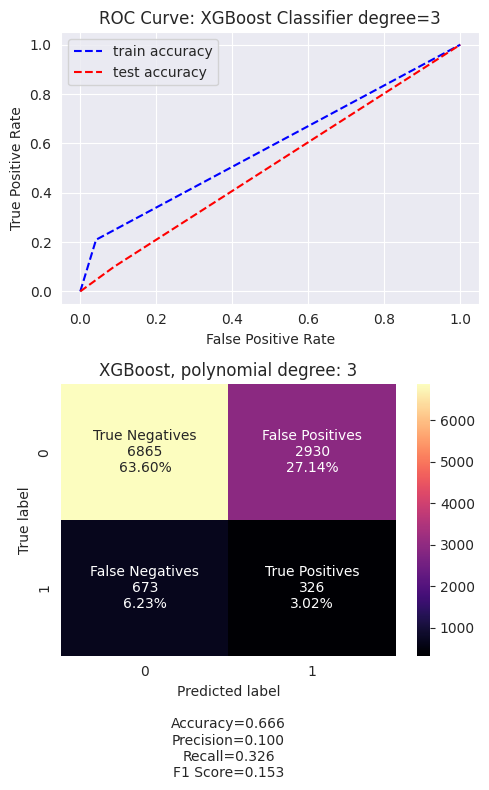

```python
fig, (ax1, ax2) = plt.subplots(2, 1, figsize=(5, 8))
kwargs = {
    "cmap": "magma",
    "group_names": ["True Negatives","False Positives","False Negatives","True Positives"],
    "title": 'XGBoost, polynomial degree: 3'
}
fpr, tpr, _ = roc_curve(train_pred, y_train)
fprts, tprts, _ = roc_curve(predictions, y_val)
utils.plot_roc(ax1, fpr,tpr,fprts,tprts,f'XGBoost Classifier degree=3')
cm = confusion_matrix(y_val, predictions)
utils.make_confusion_matrix(cm, ax2, **kwargs)
fig.tight_layout()
```

```python
# pickle.dump(xgb_clf, open("models/xgb_clf.pkl", "wb"))
```

```python
cm2 = pickle.load(open("models/compound_model_2.pkl", "rb"))
cm2
# cm2 = compound_model.make_dag()
# pickle.dump(cm2, open("models/compound_model_2.pkl", "wb"))
```

[figure not shown]

```python
cm2.fit(X_train, y_train)
cm2.score(X_val, y_val)
```

```
[14:09:16] WARNING: ../src/learner.cc:767:
Parameters: { "test_size" } are not used.
```

```
{'XGBoost': 0.6662034463590883,
 'logistic reg': 0.5672595886603669,
 'naive bayes': 0.7901612006670372}
```

```
[14:17:10] WARNING: ../src/learner.cc:767:
Parameters: { "test_size" } are not used.

[14:18:14] WARNING: ../src/learner.cc:767:
Parameters: { "test_size" } are not used.
```

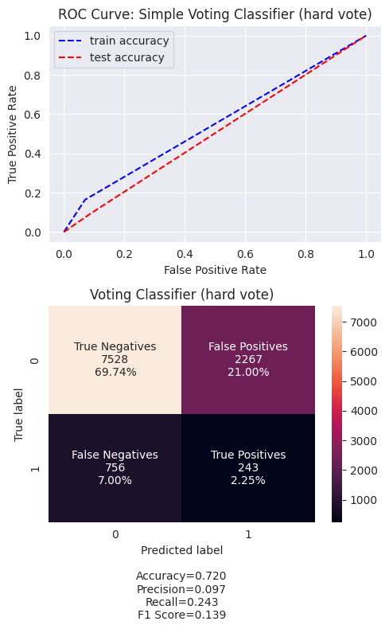

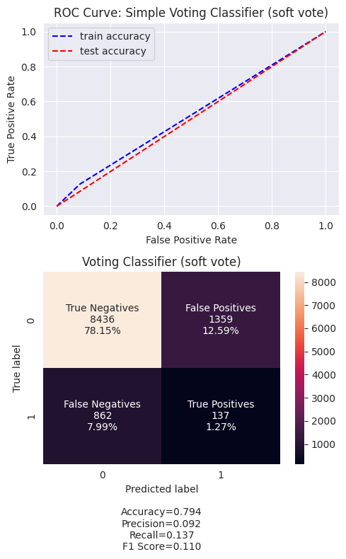

```python
for vote_type in ['hard', 'soft']:

    voting_clf = VotingClassifier(
        estimators=[('logr_clf', logr_clf), ('nb_clf', nb_clf), ('xgb_clf', xgb_clf)],
        voting=vote_type
    )


    kwargs = {
        "cmap": "rocket",
        "group_names": ["True Negatives","False Positives","False Negatives","True Positives"],
        "title": f'Voting Classifier ({vote_type} vote)'
    }

    voting_clf.fit(X_train, y_train)
    train_pred = voting_clf.predict(X_train)
    predictions = voting_clf.predict(X_val)

    fig, (ax1, ax2) = plt.subplots(2, 1, figsize=(5, 8))

    fpr, tpr, _ = roc_curve(train_pred, y_train)
    fprts, tprts, _ = roc_curve(predictions, y_val)
    utils.plot_roc(ax1, fpr,tpr,fprts,tprts,f'Simple Voting Classifier ({vote_type} vote)')

    cm = confusion_matrix(y_val, predictions)
    utils.make_confusion_matrix(cm, ax2, **kwargs)
    fig.tight_layout()
```

## Stacking

> The skdag package has a stacking API. Unfortunately, from what I can tell by briefly inspecting the skdag code myself, the stacking API doesn't implement any kind of system that would ensure that the downstream estimators are training on data that wasn't produced from fitted predictions on the previous layer (we want either data that hasn't been touched or out-of-fold (OOF) predictions). I could be completely wrong about that. But first I just wanted to create a compound model that implements a blender rather than a voting classifier.

```python
compound_model = pickle.load(open("models/compound_model_builder2.pkl", "rb"))
compound_model.add_step("xgb_blender", XGBC(random_state=101, test_size=0.25), deps={'naive bayes': 1, 'logistic reg': 1, 'XGBoost': 1})  # passing only the predictions for the 'default' class
cm_blender = compound_model.make_dag()
```

```python
cm_blender.fit(X_train, y_train)
```

```
[13:46:35] WARNING: ../src/learner.cc:767:
Parameters: { "test_size" } are not used.

[13:47:35] WARNING: ../src/learner.cc:767:
Parameters: { "test_size" } are not used.
```

[figure not shown]

```python
train_pred = cm_blender.predict_proba(X_train)
predictions = cm_blender.predict_proba(X_val)
```

> Keep in mind that the hyperparameters for the blender have not been tuned. This is just a toy model.

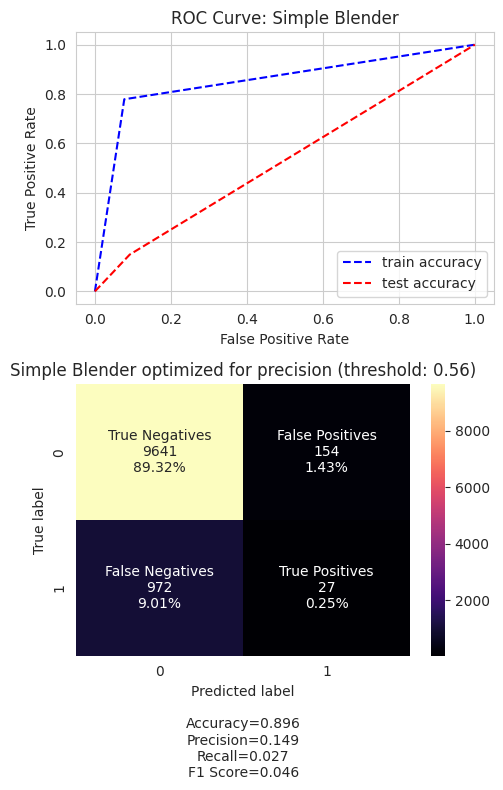

```python
from sklearn.metrics import precision_score

# we predicted probabilities this time, so we need to convert those into binary predictions using some threshold
# we can then modulate the threshold to optimize precision (or whichever metric we desire)
thresholds = np.arange(0.01, 0.7, 0.01)
precision_array = np.zeros(thresholds.shape)
for i in range(len(thresholds)):
    precision_array[i] = precision_score(y_val, predictions[:, 1] > thresholds[i])
threshold = thresholds[np.argmax(precision_array)]

kwargs = {
    "cmap": "magma",
    "group_names": ["True Negatives","False Positives","False Negatives","True Positives"],
    "title": f'Simple Blender optimized for precision (threshold:{threshold: .2f})'
}

fig, (ax1, ax2) = plt.subplots(2, 1, figsize=(5, 8))
fpr, tpr, _ = roc_curve(train_pred[:, 1] > threshold, y_train)
fprts, tprts, _ = roc_curve(predictions[:, 1] > threshold, y_val)
utils.plot_roc(ax1, fpr,tpr,fprts,tprts,f'Simple Blender')
cm = confusion_matrix(y_val, predictions[:, 1] > threshold)
utils.make_confusion_matrix(cm, ax2, **kwargs)
fig.tight_layout()
```

> To train a multi-layer ensemble, one strategy we can use is called Out Of Fold (OOF) training. We'll split the training set into `K` folds. Then for each fold `k` we'll train the layer on the training set. Once the layer is trained, we use the kth test set to make predictions, which we match up with their appropriate labels.

```python
layer_1 = pickle.load(open("models/layer_1.pkl", "rb"))
df_train = pickle.load(open("archive/df_train.pkl", "rb"))

num_observations = len(df_train)
num_layer1_models = 3
X_layer_2 = np.zeros(shape=(num_observations, num_layer1_models))  # pre-allocating space for the next layer's features
y_layer_2 = np.zeros(num_observations)  # pre-allocating for the next layer's labels

index = 0  # keeps track of where we should insert data into the pre-allocated arrays
stratified_k_fold = StratifiedKFold(n_splits=3)
for train_index, test_index in stratified_k_fold.split(df_train.drop(target_var, axis=1), df_train[target_var]):
    X_tr = df_train.iloc[train_index, :-1]
    X_tst = df_train.iloc[test_index, :-1]
    y_tr = df_train[target_var].iloc[train_index]
    y_tst = df_train[target_var].iloc[test_index]

    # train the models for this fold
    layer_1.fit(X_tr, y_tr)

    # make predictions for the testing portion (note this is not the test set proper!)
    predictions = layer_1.predict_proba(X_tst)

    # insert data into pre-allocated arrays
    size = len(X_tst)
    print(f'size: {size}')
    X_layer_2[index : index + size] = predictions
    y_layer_2[index : index + size] = y_tst

    # increment index
    index = index + size
```

```
[20:38:22] WARNING: ../src/learner.cc:767:
Parameters: { "test_size" } are not used.

size: 17990
[20:39:58] WARNING: ../src/learner.cc:767:
Parameters: { "test_size" } are not used.

size: 17990
[20:42:41] WARNING: ../src/learner.cc:767:
Parameters: { "test_size" } are not used.

size: 17990
```

```python
layer_2_training = pickle.load(open("archive/layer_2_training_set.pkl", "rb"))
```

> Now that we have training data for the second layer, we need to build a second layer!

```python
sss = StratifiedShuffleSplit(n_splits=1, test_size=0.2, random_state=101)
for train_index, test_index in sss.split(layer_2_training.X, layer_2_training.y):
    X_train, y_train = layer_2_training.X[train_index], layer_2_training.y[train_index]
    X_val, y_val = layer_2_training.X[test_index], layer_2_training.y[test_index]
```

```python
# Values found experimentally with RandomSearchCV
rf_params = {
 'random_state': 42,
 'n_estimators': 200,
 'n_jobs': -1,
 'min_samples_split': 5,
 'min_samples_leaf': 2,
 'max_features': 'log2',
 'max_depth': 3,
 'criterion': 'gini',
 'class_weight': None,
 'bootstrap': True
}

rf_pipe = Pipeline([
    ("poly", PolynomialFeatures(degree=5)),
    ("scale", StandardScaler()),
    ("rand_forest", RandomForestClassifier(**rf_params))
])

rf_pipe.fit(X_train, y_train)
```

```
Pipeline(steps=[('poly', PolynomialFeatures(degree=5)),
                ('scale', StandardScaler()),
                ('rand_forest',
                 RandomForestClassifier(max_depth=3, max_features='log2',
                                        min_samples_leaf=2, min_samples_split=5,
                                        n_estimators=200, n_jobs=-1,
                                        random_state=42))])
```

## Adding a second layer

In a separate notebook I tuned RandomForest, XGBoost, and KNearestNeighbors classifiers to use for the second layer

We can load the DAGBuilder for the first layer that was cached earlier and then just add the second layer estimators

```python
compound_model = pickle.load(open("models/compound_model_builder2.pkl", "rb"))
compound_model
```

[figure not shown]

```python
ensemble_2_layer_buidler = (
    compound_model

    .add_step(
        "random forest",
        pickle.load(open("models/rf_clf_dag.pkl", "rb")),
        deps={"naive bayes": 1, "logistic reg": 1, "XGBoost": 1}
    )

    .add_step(
        "XGBoost_l2",
        pickle.load(open("models/xgb_clf2_dag.pkl", "rb")),
        deps={"naive bayes": 1, "logistic reg": 1, "XGBoost": 1}
    )

    .add_step(
        "knn",
        pickle.load(open("models/knn_clf_dag.pkl", "rb")),
        deps={"naive bayes": 1, "logistic reg": 1, "XGBoost": 1}
    )

    .add_step(
        "merge_l2",
        "passthrough",
        deps={"random forest": 1, "XGBoost_l2": 1, "knn": 1}
    )
)

ensemble_2_layer_buidler
```

[figure not shown]

and cache it of course. Keep in mind that although the two layer model has been constructed here with the DAGBuilder, I don't know how the stacking API implements training, so to ensure that each layer is getting "clean" data I'll be implementing the layers separately and then manually passing the output of one layer to the input of the next. I'll also test the stacking API version, and compare the results, though for that comparison to be meaningful it will make the assumption that I was able to get both models to perform optimally, which is perhaps a tall order.

```python
# pickle.dump(ensemble_2_layer_buidler, open("models/ensemble_2_layer_builer.pkl", "wb"))
```

Once again we can use the OOF strategy to produce a training set for the final estimator

```python
cm = compound_model.add_step("merge", "passthrough", deps={"naive bayes": 1, "logistic reg": 1, "XGBoost": 1}).make_dag()
```

```python
cm.fit(X_train, y_train)
```

```
[18:07:27] WARNING: ../src/learner.cc:767:
Parameters: { "test_size" } are not used.
```

```
array([[1.        , 0.51337446, 0.32396159],
       [0.05054175, 0.49592812, 0.30988458],
       [0.03167747, 0.49455242, 0.47810552],
       ...,
       [0.17796869, 0.50061831, 0.44547758],
       [0.80202104, 0.51318235, 0.5992099 ],
       [0.9818413 , 0.51526884, 0.62760335]])
```

```python
# pickle.dump(cm, open("models/layer_1_trained.pkl", "wb"))
```

```python
layer2_buidler = (
    DAGBuilder()

    .add_step(
        "input",
        "passthrough"
    )

    .add_step(
        "random forest",
        pickle.load(open("models/rf_clf_dag.pkl", "rb")),
        deps=["input"]
    )

    .add_step(
        "XGBoost_l2",
        pickle.load(open("models/xgb_clf2_dag.pkl", "rb")),
        deps=["input"]
    )

    .add_step(
        "knn",
        pickle.load(open("models/knn_clf_dag.pkl", "rb")),
        deps=["input"]
    )

    .add_step(
        "merge_l2",
        "passthrough",
        deps={"random forest": 1, "XGBoost_l2": 1, "knn": 1}
    )
)
```

```python
l2 = layer2_buidler.make_dag()
l2.fit(X_train, y_train)
```

```
[18:18:35] WARNING: ../src/learner.cc:767:
Parameters: { "min_samples_leaf", "min_samples_split", "test_size" } are not used.
```

[figure not shown]

```python
pickle.dump(layer2_buidler, open("models/layer_2_builder.pkl", "wb"))
pickle.dump(l2, open("models/layer2_trained.pkl", "wb"))
```

```python
l1 = pickle.load(open("models/layer_1_trained.pkl", "rb"))
l2 = pickle.load(open("models/layer2_trained.pkl", "rb"))

two_layer_model = (
    DAGBuilder()
    .add_step(
        "layer1",
        l1
    )
    .add_step(
        "layer2",
        l2,
        deps=['layer1']
    )
).make_dag()
```

```python
two_layer_model
```

```python
pickle.dump(two_layer_model, open("models/trained_two_layer_model.pkl", "wb"))
```

```python
layer_2 = pickle.load(open("models/layer2_trained.pkl", "rb"))
l2t = pickle.load(open("archive/layer_2_training_set.pkl", "rb"))

num_observations = len(l2t.X)
num_layer2_models = 3
X_layer_3 = np.zeros(shape=(num_observations, num_layer2_models))  # pre-allocating space for the next layer's features
y_layer_3 = np.zeros(num_observations)  # pre-allocating for the next layer's labels
#
index = 0  # keeps track of where we should insert data into the pre-allocated arrays
stratified_k_fold = StratifiedKFold(n_splits=3)
for train_index, test_index in stratified_k_fold.split(l2t.X, l2t.y):
    X_tr = l2t.X[train_index]
    X_tst = l2t.X[test_index]
    y_tr = l2t.y[train_index]
    y_tst = l2t.y[test_index]

    # train the models for this fold
    layer_2.fit(X_tr, y_tr)

    # make predictions for the testing portion (note this is not the test set proper!)
    predictions = layer_2.predict_proba(X_tst)

    # insert data into pre-allocated arrays
    size = len(X_tst)
    print(f'size: {size}')
    X_layer_3[index : index + size] = predictions
    y_layer_3[index : index + size] = y_tst

    # increment index
    index = index + size
```

```
[18:39:07] WARNING: ../src/learner.cc:767:
Parameters: { "min_samples_leaf", "min_samples_split", "test_size" } are not used.

size: 17990
[18:39:16] WARNING: ../src/learner.cc:767:
Parameters: { "min_samples_leaf", "min_samples_split", "test_size" } are not used.

size: 17990
[18:39:23] WARNING: ../src/learner.cc:767:
Parameters: { "min_samples_leaf", "min_samples_split", "test_size" } are not used.

size: 17990
```

```python
from utils import Training_Set

layer_3_training_set = Training_Set(X_layer_3, y_layer_3)
pickle.dump(layer_3_training_set, open("archive/layer_3_training_set.pkl", "wb"))
```

```python
layer_3_training_set.X
```

```
array([[0.09109909, 0.09614037, 0.        ],
       [0.09356818, 0.09614037, 0.        ],
       [0.09266204, 0.09082196, 0.        ],
       ...,
       [0.09394541, 0.09858348, 0.19807652],
       [0.08232263, 0.07240669, 0.23977423],
       [0.09241095, 0.09161853, 0.        ]])
```

## Tuning the Blender

```python
layer_3_training = pickle.load(open("archive/layer_3_training_set.pkl", "rb"))

sss = StratifiedShuffleSplit(n_splits=1, test_size=0.2, random_state=101)
for train_index, test_index in sss.split(layer_3_training.X, layer_3_training.y):
    X_train, y_train = layer_3_training.X[train_index], layer_3_training.y[train_index]
    X_val, y_val = layer_3_training.X[test_index], layer_3_training.y[test_index]
```

```python
X_train.shape
```

```
(43176, 3)
```

```python
blender_pipe = Pipeline([
    ("polyfeat", PolynomialFeatures(degree=3)),
    ("scaler", StandardScaler())
])
```

```python
from sklearn.ensemble import AdaBoostClassifier

adaparams = {
    'n_estimators': 200,
    'learning_rate': 0.1,
    'algorithm': 'SAMME.R',
    'random_state': 42
}

ada_clf = AdaBoostClassifier(**adaparams)

X_prep = blender_pipe.fit_transform(X_train)

ada_clf.fit(X_prep, y_train)
```

```
AdaBoostClassifier(learning_rate=0.1, n_estimators=200, random_state=42)
```

```python
ada_clf.score(X_prep, y_train)
```

```
0.9075180655919955
```

```python
ada_clf.score(blender_pipe.transform(X_val), y_val)
```

```
0.9074485825458588
```

```python
predictions = ada_clf.predict_proba(blender_pipe.transform(X_val))[:, 1]
train_pred = ada_clf.predict_proba(X_prep)[:, 1]
```

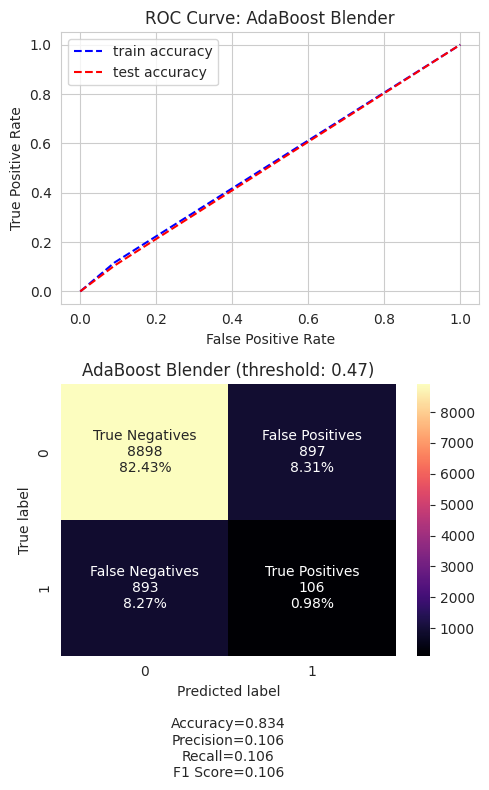

```python
thresholds = np.arange(0.47, 0.479, 0.00001)
precision_array = np.zeros(thresholds.shape)
recall_array = np.zeros(thresholds.shape)
for i in range(len(thresholds)):
    precision_array[i] = precision_score(y_val, predictions > thresholds[i])
    recall_array[i] = recall_score(y_val, predictions > thresholds[i])
threshold = thresholds[np.argmin(np.abs(precision_array - recall_array))]

kwargs = {
    "cmap": "magma",
    "group_names": ["True Negatives","False Positives","False Negatives","True Positives"],
    "title": f'AdaBoost Blender (threshold:{threshold: .2f})'
}

fig, (ax1, ax2) = plt.subplots(2, 1, figsize=(5, 8))
fpr, tpr, _ = roc_curve(train_pred > threshold, y_train)
fprts, tprts, _ = roc_curve(predictions > threshold, y_val)
utils.plot_roc(ax1, fpr,tpr,fprts,tprts,f'AdaBoost Blender')
cm = confusion_matrix(y_val, predictions > threshold)
utils.make_confusion_matrix(cm, ax2, **kwargs)
fig.tight_layout()
```

```python
threshold
```

```
0.4722200000000022
```

```python
X_train_prep = blender_pipe.fit_transform(X_train)
```

```python
import tensorflow as tf
from tensorflow import keras
from keras import regularizers

# Define the model architecture
model = keras.Sequential([
    keras.layers.Dense(1500, activation='relu', input_shape=(20,)),
    keras.layers.Dense(1500, activation='relu'),
    keras.layers.Dense(256, activation='relu'),
    keras.layers.Dense(1, activation='sigmoid')
])

# Compile the model
model.compile(optimizer='adam', loss='binary_crossentropy', metrics=['categorical_accuracy'])
```

```python
model.fit(X_train_prep, y_train)
```

```
<keras.callbacks.History at 0x7f7f04652950>
```

```python
X_val_prep = blender_pipe.transform(X_val)
```

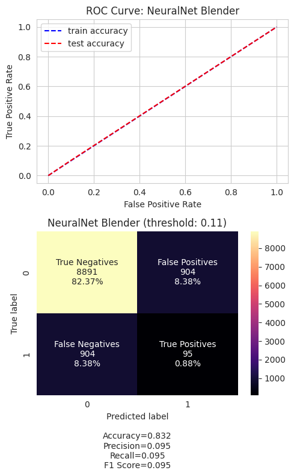

```python
predictions = model.predict(X_val_prep)
train_pred = model.predict(X_train_prep)

thresholds = np.arange(0.04, 0.2, 0.00001)
precision_array = np.zeros(thresholds.shape)
recall_array = np.zeros(thresholds.shape)
for i in range(len(thresholds)):
    precision_array[i] = precision_score(y_val, predictions > thresholds[i])
    recall_array[i] = recall_score(y_val, predictions > thresholds[i])
threshold = thresholds[np.argmin(np.abs(precision_array - recall_array))]

kwargs = {
    "cmap": "magma",
    "group_names": ["True Negatives","False Positives","False Negatives","True Positives"],
    "title": f'NeuralNet Blender (threshold:{threshold: .2f})'
}

fig, (ax1, ax2) = plt.subplots(2, 1, figsize=(5, 8))
fpr, tpr, _ = roc_curve(train_pred > threshold, y_train)
fprts, tprts, _ = roc_curve(predictions > threshold, y_val)
utils.plot_roc(ax1, fpr,tpr,fprts,tprts,f'NeuralNet Blender')
cm = confusion_matrix(y_val, predictions > threshold)
utils.make_confusion_matrix(cm, ax2, **kwargs)
fig.tight_layout()
```